# MSDS597 Final Project

Wei Yuan

## Wraging Movie Data

### 1. Collecting data

I collect only the first 500 of IMDB and all from the Numbers. The main problem is how to scrape multiple pages. By looking at the url of the two websites carefully, we can find that there are choices to set the starting index and we can scrape the data piece by piece and then merge the data to a large data frame. The IMDB website url gives the choice after the string “start=”, and the Numbers after string “all/”. There is a userful tool called Selector Gadget, I use it to determine the nodes I need to focus on. There is a problem actually, the Numbers website has the mechanism for anti-scraping, and my program shut down after a while, so I have to manually copy all the data from the website and asve them as a txt file. Then I open it in R. I will paste my code for scraping here and the data I saved will be shown in my Github Repository.

```r
# the Numbers
# url_numbers <- 'https://www.the-numbers.com/movie/budgets/all/'

# blocked by anti-scrapying mechanism
# index <- seq(1, 6001, 100)
#
# numbers <- NULL
# for (i in index) {
#   url <- paste0(url_numbers, toString(i))
#   numbers_temp <- url_numbers %>%
#     read_html() %>%
#     html_nodes('table') %>%
#     html_table(fill = TRUE) %>%
#     .[[1]]
#   numbers <- rbind(numbers, numbers_temp)
# }
#
# write.csv(numbers, file = '', row.names = FALSE)
```

Here is a look at the raw data of IMDB.

```r
glimpse(imdb)
```

```
## Observations: 500
## Variables: 10
## $ rank        <fct> 1., 2., 3., 4., 5., 6., 7., 8., 9., 10., 11., 12., 13.,...
## $ title       <fct> Inception, The Dark Knight Rises, Interstellar, Django ...
## $ rating      <fct> 8.8, 8.4, 8.6, 8.4, 8.0, 8.2, 8.1, 8.0, 8.0, 8.1, 7.9, ...
## $ year        <fct> (2010), (2012), (2014), (2012), (2012), (2013), (2010),...
## $ runTime     <fct> 148 min, 164 min, 169 min, 165 min, 143 min, 180 min, 1...
## $ genre       <fct> "\nAction, Adventure, Sci-Fi            ", "\nAction, A...
## $ votes       <fct> "1,957,531", "1,458,113", "1,408,356", "1,291,039", "1,...
## $ gross       <fct> $292.58M, $448.14M, $188.02M, $162.81M, $623.28M, $116....
## $ staff       <fct> "\n    Director:\nChristopher Nolan\n                 |...
## $ description <fct> "\n    A thief who steals corporate secrets through the...
```

```r
numbers <- read_tsv('https://raw.githubusercontent.com/ywwes26/IMDB-Numbers-Project/master/raw-data/numbers.txt')
numbers <- rbind(names(numbers), numbers)
numbers <- numbers[,-1]
names(numbers) <- c('releaseDate', 'title', 'budget', 'domesticGross', 'worldwideGross')
```

The glimpse of the Numbers data.

```r
glimpse(numbers)
```

```
## Observations: 6,030
## Variables: 5
## $ releaseDate    <chr> "Apr 23, 2019", "May 20, 2011", "Apr 22, 2015", "Dec...
## $ title          <chr> "Avengers: Endgame", "Pirates of the Caribbean: On S...
## $ budget         <chr> "$400,000,000", "$379,000,000", "$365,000,000", "$30...
## $ domesticGross  <chr> "$858,373,000", "$241,063,875", "$459,005,868", "$93...
## $ worldwideGross <chr> "$2,797,800,564", "$1,045,663,875", "$1,403,013,963"...
```

### 2. Cleanign the data

From the format of the raw data we can seee that there are a lot of useless symbols in the data, and some columns are united too, and we need to separate them. There are also problems like multiple genres of a movie, and multiple directors and stars too. The following solutions are adopted to get the data clean. 1. Remove useless symbols like “,”, “.”, “(”, “$” and so on. The function used here is the str_remove_all(). 2. Part of title is in the column year. Use extract_all() and paste0() to fix this problem. 3. Extract the first genre and director of movies to subsititute the original data. 4. Remove the blanks using str_trim(). 5. Transfer the unit of budget and gross.

The cleaned data of IMDB.

```r
glimpse(imdb)
```

```
## Observations: 500
## Variables: 11
## $ rank        <int> 1, 2, 3, 4, 5, 6, 7, 8, 9, 10, 11, 12, 13, 14, 15, 16, ...
## $ title       <chr> "Inception", "The Dark Knight Rises", "Interstellar", "...
## $ rating      <dbl> 8.8, 8.4, 8.6, 8.4, 8.0, 8.2, 8.1, 8.0, 8.0, 8.1, 7.9, ...
## $ year        <dbl> 2010, 2012, 2014, 2012, 2012, 2013, 2010, 2014, 2016, 2...
## $ runTime     <dbl> 148, 164, 169, 165, 143, 180, 138, 121, 108, 120, 138, ...
## $ genre       <chr> "Action", "Action", "Adventure", "Drama", "Action", "Bi...
## $ votes       <dbl> 1957531, 1458113, 1408356, 1291039, 1228852, 1112225, 1...
## $ gross       <dbl> 292.58, 448.14, 188.02, 162.81, 623.28, 116.90, 128.01,...
## $ director    <chr> "Christopher Nolan", "Christopher Nolan", "Christopher ...
## $ stars       <chr> "Leonardo DiCaprio, Joseph Gordon-Levitt, Ellen Page, K...
## $ description <chr> "A thief who steals corporate secrets through the use o...
```

The cleaned data of the Numbers.

```r
glimpse(numbers)
```

```
## Observations: 6,030
## Variables: 5
## $ releaseDate    <chr> "Apr 23, 2019", "May 20, 2011", "Apr 22, 2015", "Dec...
## $ title          <chr> "Avengers: Endgame", "Pirates of the Caribbean: On S...
## $ budget         <dbl> 400.0, 379.0, 365.0, 306.0, 300.0, 300.0, 300.0, 300...
## $ domesticGross  <dbl> 858.37300, 241.06387, 459.00587, 936.66223, 678.8154...
## $ worldwideGross <dbl> 2797.8006, 1045.6639, 1403.0140, 2068.2236, 2048.359...
```

### 3. Analyzing

#### a. Analysis about the genres.

I want to find the the rating within each genre, to find out which kind of movies are more popuplar, so I create a boxplot in each genre and compare them. The surprise is that the biography has the higest rating average, not action movie. The plot is shown below.

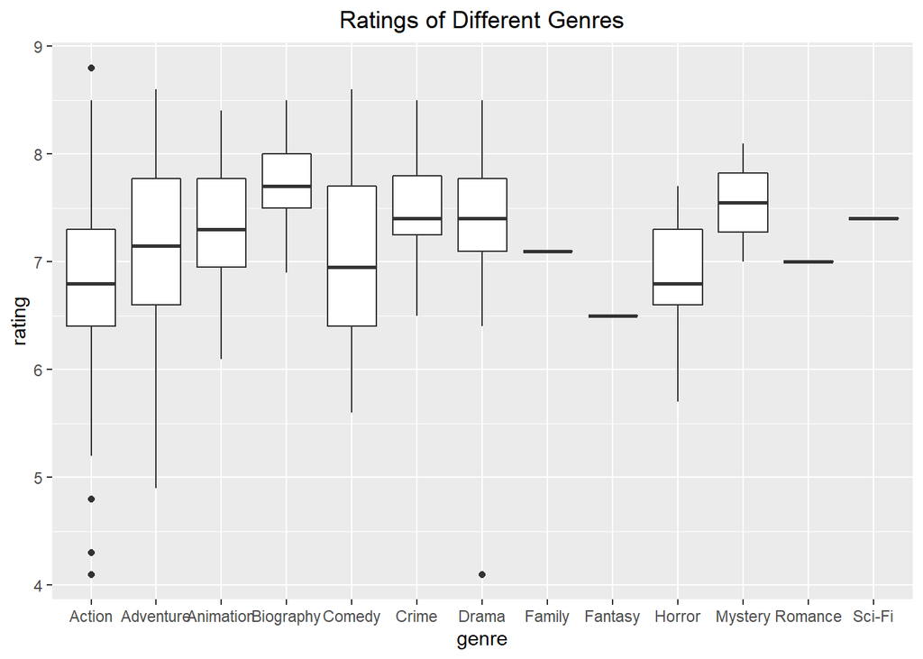

```r
# the rating of different genres
ggplot(data = imdb) +
  geom_boxplot(aes(genre, rating)) +
  ggtitle('Ratings of Different Genres') +
  theme(plot.title = element_text(hjust = 0.5))
```

The next analysis I do is that I think the votes on IMDB indicate the popularity of the movies, so I investigate the votes within each genre. There is a surprise too that the mystery movies has the highest votes.

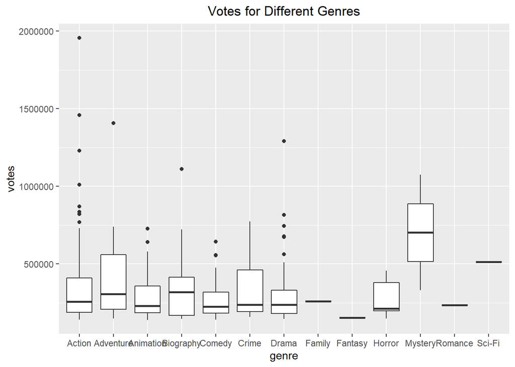

```r
# votes indicate popularity
ggplot(data = imdb) +
  geom_boxplot(aes(genre, votes)) +
  ggtitle('Votes for Different Genres') +
  theme(plot.title = element_text(hjust = 0.5))
```

#### b. Analysis of the gross.

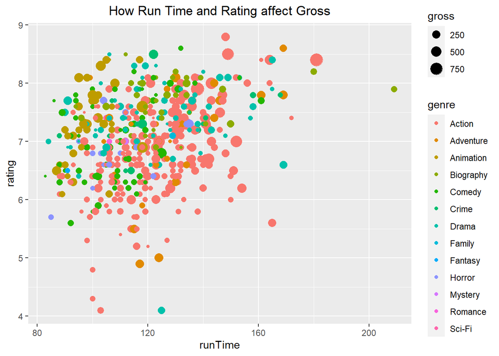

```r
ggplot(data = imdb,aes(runTime,rating)) +
  geom_point(aes(size=gross,col=genre)) +
  ggtitle('How Run Time and Rating affect Gross') +
  theme(plot.title = element_text(hjust = 0.5))
```

The second investigation about gross is that how much gross increase when we increase investment. What is interesting is that when we increase budget, the world wide gross increase much more than domestic gross. The slope is steeper.

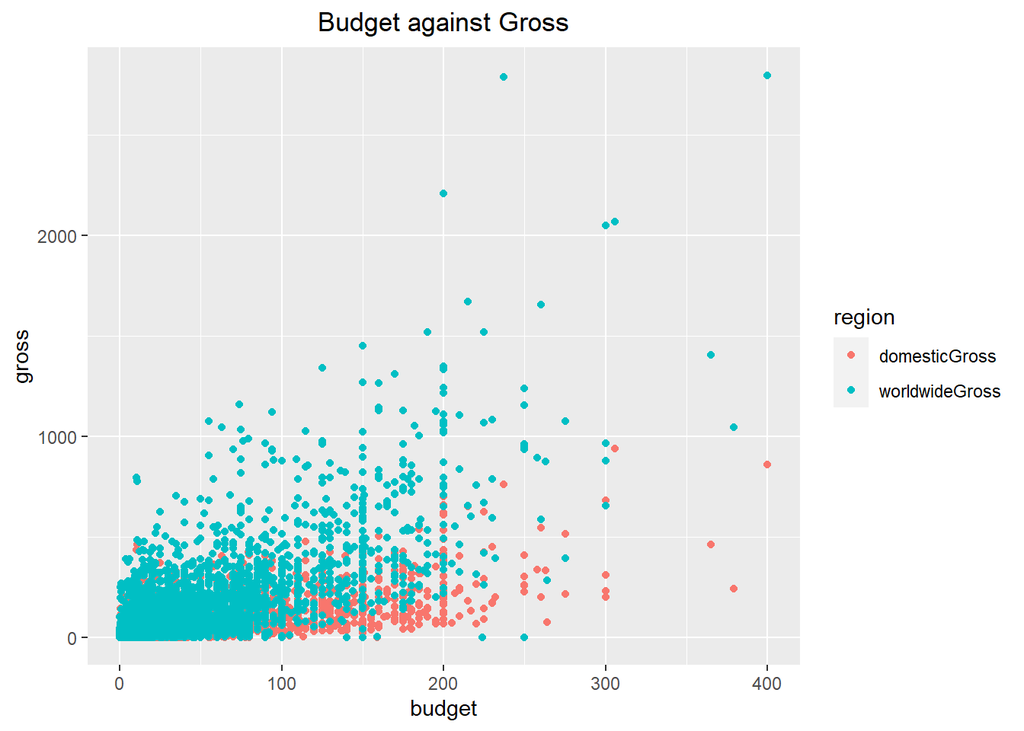

```r
# will high investment improve the gross?
numbers[-2300,] %>%  # remove outlier
  gather(`domesticGross`:`worldwideGross`,key = 'region', value = gross) %>%
  ggplot() + geom_point(aes(budget, gross, color = region)) +
  ggtitle('Budget against Gross') +
  theme(plot.title = element_text(hjust = 0.5))
```

#### c. Directors and actors.

The next finding is the top actors and directors. Here I collect data of the top votes, so we can see popularity of these people.

```r
# famous actors and directors
directors <- table(imdb$director) %>%
  as.data.frame() %>%
  arrange(desc(Freq)) %>%
  .[1:10,]
names(directors) <- c('Director','Number of Show-ups')
directors
```

```
##             Director Number of Show-ups
## 1          James Wan                  6
## 2        David Yates                  5
## 3   Denis Villeneuve                  5
## 4        Jon Favreau                  5
## 5       Ridley Scott                  5
## 6   Steven Spielberg                  5
## 7      Todd Phillips                  5
## 8      Anthony Russo                  4
## 9      Antoine Fuqua                  4
## 10 Christopher Nolan                  4
```

```r
actor_list <- NULL
for (i in 1:500) {
  actor <- imdb$stars[i] %>%
    str_split(',') %>%
    unlist()
  actor_list <- c(actor_list, actor)
}
actors <- table(actor_list) %>%
  as.data.frame() %>%
  arrange(desc(Freq)) %>%
  .[1:10,]
names(actors) <- c('Actor', 'Number of Show-ups')
actors
```

```
##                  Actor Number of Show-ups
## 1    Samuel L. Jackson                  9
## 2    Robert Downey Jr.                  9
## 3           Tom Cruise                  9
## 4        Anne Hathaway                  8
## 5   Scarlett Johansson                  8
## 6      Woody Harrelson                  8
## 7       Dwayne Johnson                  8
## 8      Jake Gyllenhaal                  8
## 9          Johnny Depp                  8
## 10      Cate Blanchett                  7
```

I am also intersted in the word most frequently used in the description of the movie. So I made a word cloud of it. First I need to separate the sentences using unnest_tokens() and then remove the stop words in it. Then make the word cloud by frequency.

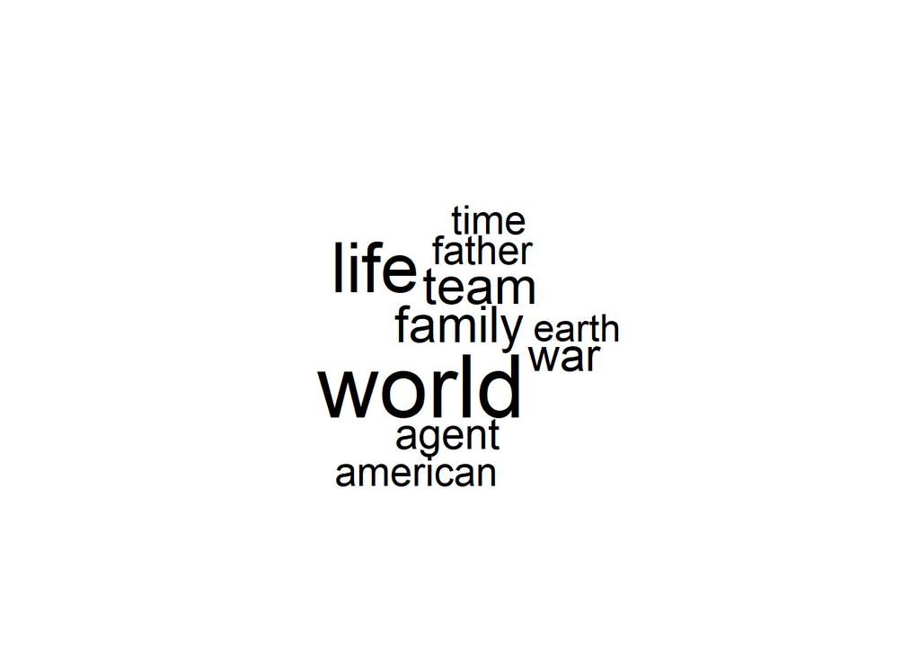

```r
# wordcloud for description
data('stop_words')
descrip <- imdb %>%
  unnest_tokens(word, description) %>%
  anti_join(stop_words) %>%
  count(word, sort = T)
descrip[1:10,] %>% with(wordcloud(word,n))
```

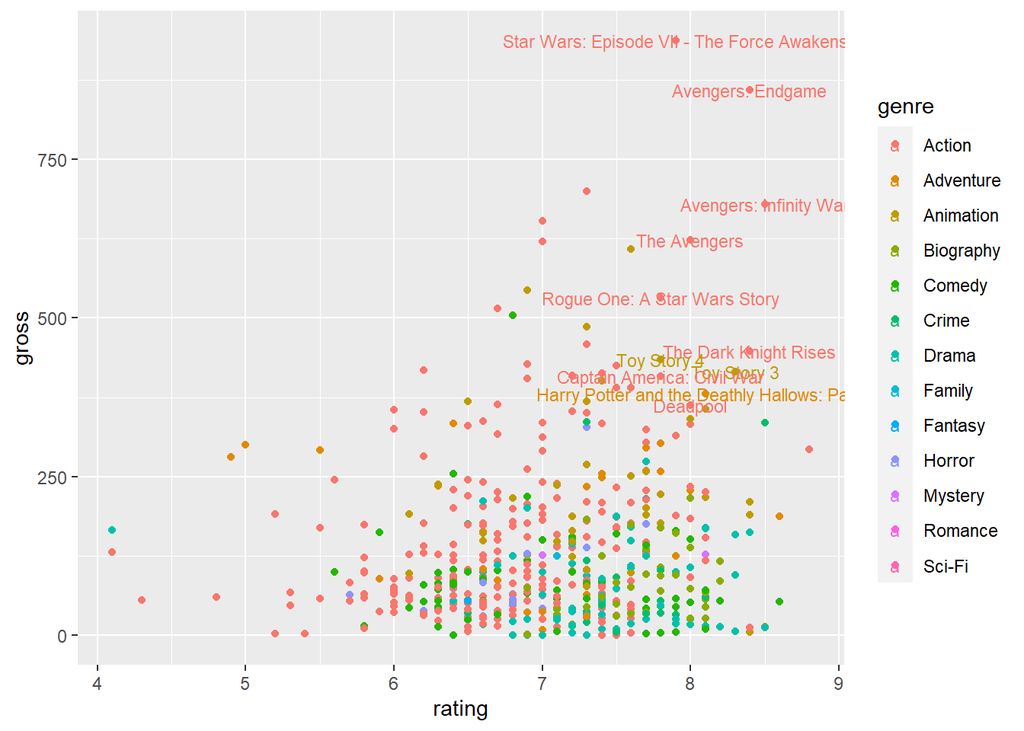

```r
hot_movies <- imdb %>%
  filter(rating >= 7.8) %>%
  filter(gross >= 360)
ggplot(data = imdb, aes(rating, gross, color = genre, label = title)) + geom_point() +
  geom_text(aes(label = title), data = hot_movies, size = 3)
```

### 4. Conclusion

This project helps me review what I learned in this course, and the important thing is that I improve myself by challeging more complicated web scraping and using Github to do project management. Overall, this is a nice course and I will keep learning data wrangling and enhance y skills. Here is the Github repository for this project. https://github.com/ywwes26/IMDB-Numbers-Project